# Listening to Seattle’s birds with Convolutional Neural Networks

## Dataset

### Master dataset

- Transpose the data into the format that a CNN would expect
- Normalize spectrogram values to improve convergence speed and gradient behavior (neural networks train more stably when inputs are on a consistent scale)
- Add CNN channel dimension because CNNs expect (gray-scale) image-like input

```python
X_all = []
y_all = []

for species in species_keys:
    data = f[species][:]
    data = np.transpose(data, (2, 0, 1))
    X_all.append(data)
    y_all.extend([species] * data.shape[0])

X_all = np.concatenate(X_all, axis=0)
y_all = np.array(y_all)

print("X_all shape:", X_all.shape)
print("y_all shape:", y_all.shape)
```

```
X_all shape: (1981, 128, 517)
y_all shape: (1981,)
```

```python
X_all = X_all.astype("float32")
X_min = X_all.min()
X_max = X_all.max()
X_all = (X_all - X_min) / (X_max - X_min)
print(X_all.min(), X_all.max())
```

```
0.0 1.0
```

```python
X_all = X_all[..., np.newaxis]
print(X_all.shape)
```

```
(1981, 128, 517, 1)
```

### Binary subset

The binary subset will include the House Sparrow and the Song Sparrow.

```python
binary_mask = np.isin(y_all,["houspa", "sonspa"])

X_binary = X_all[binary_mask]
y_binary = y_all[binary_mask]
```

```python
print(X_binary.shape)
print(y_binary.shape)
```

```
(893, 128, 517, 1)
(893,)
```

```python
encoder = LabelEncoder()
y_binary_encoded = encoder.fit_transform(y_binary)
print(encoder.classes_)
```

```
['houspa' 'sonspa']
```

### Multiclass subset

- Each bird should have 300 samples.
- If they have more than 300, we are only keeping 300.
- If they have less than 300, we use SpecAugment.

```python
# data augmentation function
def spec_augment(spectrogram,freq_mask_param=10,time_mask_param=20):
    augmented = spectrogram.copy()

    # frequency mask
    freq_mask_size = np.random.randint(0, freq_mask_param)
    freq_start = np.random.randint(0,augmented.shape[0] - freq_mask_size)
    augmented[freq_start:freq_start + freq_mask_size,:] = 0


    # time mask
    time_mask_size = np.random.randint(0, time_mask_param)
    time_start = np.random.randint(0,augmented.shape[1] - time_mask_size)
    augmented[:,time_start:time_start + time_mask_size] = 0

    return augmented
```

```python
X_multi = []
y_multi = []

target_samples = 300

for species in species_keys:
    print(f"\nProcessing species: {species}")
    species_mask = (y_all == species)
    X_species = X_all[species_mask]
    n_original = X_species.shape[0]
    print(f"Original samples: {n_original}")
    X_species_final = list(X_species)

    # augment only minority samples
    if n_original < target_samples:
        n_needed = target_samples - n_original
        print(f"Generating {n_needed} augmented samples")

        for i in range(n_needed):
            idx = np.random.randint(0, n_original)
            original_spec = X_species[idx]
            augmented_spec = spec_augment(original_spec)
            X_species_final.append(augmented_spec)

    else:
        selected_idx = np.random.choice(n_original,size=target_samples,replace=False)
        X_species_final = list(X_species[selected_idx])

    X_species_final = np.array(X_species_final)
    X_multi.append(X_species_final)
    y_multi.extend([species] * len(X_species_final))
```

```
Processing species: amecro
Original samples: 66
Generating 234 augmented samples

Processing species: amerob
Original samples: 172
Generating 128 augmented samples

Processing species: bewwre
Original samples: 144
Generating 156 augmented samples

Processing species: bkcchi
Original samples: 45
Generating 255 augmented samples

Processing species: daejun
Original samples: 125
Generating 175 augmented samples

Processing species: houfin
Original samples: 84
Generating 216 augmented samples

Processing species: houspa
Original samples: 630

Processing species: norfli
Original samples: 37
Generating 263 augmented samples

Processing species: rewbla
Original samples: 187
Generating 113 augmented samples

Processing species: sonspa
Original samples: 263
Generating 37 augmented samples

Processing species: spotow
Original samples: 137
Generating 163 augmented samples

Processing species: whcspa
Original samples: 91
Generating 209 augmented samples
```

```python
X_multi = np.concatenate(X_multi, axis=0)
y_multi = np.array(y_multi)

print("\nFINAL MULTICLASS DATASET")
print("X_multi shape:", X_multi.shape)
print("y_multi shape:", y_multi.shape)
```

```
FINAL MULTICLASS DATASET
X_multi shape: (3600, 128, 517, 1)
y_multi shape: (3600,)
```

```python
class_counts = pd.Series(y_multi).value_counts()
print(class_counts)
```

```
amecro    300
amerob    300
bewwre    300
bkcchi    300
daejun    300
houfin    300
houspa    300
norfli    300
rewbla    300
sonspa    300
spotow    300
whcspa    300
Name: count, dtype: int64
```

## Binary Classification

```python
# train test split
X_train, X_test, y_train, y_test = train_test_split(X_binary,y_binary_encoded,test_size=0.2,stratify=y_binary_encoded,random_state=42)

print(X_train.shape)
print(X_test.shape)
```

```
(714, 128, 517, 1)
(179, 128, 517, 1)
```

### First Binary Model

- Spectrogram representation is working
- CNN is able to learn meaningful acoustic patterns
- CNN is able to distinguish between the two birds
- The main issue is class imbalance and poorer minority class recall
- The model misses 25% of Song Sparrow samples
- Proposed improvement: don't make the model more complex. Add class weights to address imbalance.

```python
# base architecture
baseline_model = Sequential([
    Conv2D(32,(3,3),activation='relu',input_shape=(128, 517, 1)),
    MaxPooling2D((2,2)),
    Conv2D(64,(3,3),activation='relu'),
    MaxPooling2D((2,2)),
    Flatten(),
    Dense(64, activation='relu'),
    Dense(1, activation='sigmoid')])
```

[output not shown]

```python
baseline_model.compile(optimizer='adam',loss='binary_crossentropy',metrics=['accuracy'])
```

```python
baseline_model.summary()
```

```
Model: "sequential"
```

```
┏━━━━━━━━━━━━━━━━━━━━━━━━━━━━━━━━━┳━━━━━━━━━━━━━━━━━━━━━━━━┳━━━━━━━━━━━━━━━┓
┃ Layer (type)                    ┃ Output Shape           ┃       Param # ┃
┡━━━━━━━━━━━━━━━━━━━━━━━━━━━━━━━━━╇━━━━━━━━━━━━━━━━━━━━━━━━╇━━━━━━━━━━━━━━━┩
│ conv2d (Conv2D)                 │ (None, 126, 515, 32)   │           320 │
├─────────────────────────────────┼────────────────────────┼───────────────┤
│ max_pooling2d (MaxPooling2D)    │ (None, 63, 257, 32)    │             0 │
├─────────────────────────────────┼────────────────────────┼───────────────┤
│ conv2d_1 (Conv2D)               │ (None, 61, 255, 64)    │        18,496 │
├─────────────────────────────────┼────────────────────────┼───────────────┤
│ max_pooling2d_1 (MaxPooling2D)  │ (None, 30, 127, 64)    │             0 │
├─────────────────────────────────┼────────────────────────┼───────────────┤
│ flatten (Flatten)               │ (None, 243840)         │             0 │
├─────────────────────────────────┼────────────────────────┼───────────────┤
│ dense (Dense)                   │ (None, 64)             │    15,605,824 │
├─────────────────────────────────┼────────────────────────┼───────────────┤
│ dense_1 (Dense)                 │ (None, 1)              │            65 │
└─────────────────────────────────┴────────────────────────┴───────────────┘
```

```
 Total params: 15,624,705 (59.60 MB)
```

```
 Trainable params: 15,624,705 (59.60 MB)
```

```
 Non-trainable params: 0 (0.00 B)
```

```python
history = baseline_model.fit(X_train,y_train,epochs=10,batch_size=16,validation_split=0.2)
```

```
36/36 ━━━━━━━━━━━━━━━━━━━━ 35s 859ms/step - accuracy: 0.6405 - loss: 1.4765 - val_accuracy: 0.6434 - val_loss: 0.6087
36/36 ━━━━━━━━━━━━━━━━━━━━ 29s 793ms/step - accuracy: 0.6899 - loss: 0.5937 - val_accuracy: 0.6713 - val_loss: 0.5748
36/36 ━━━━━━━━━━━━━━━━━━━━ 28s 791ms/step - accuracy: 0.7386 - loss: 0.5366 - val_accuracy: 0.7273 - val_loss: 0.5316
36/36 ━━━━━━━━━━━━━━━━━━━━ 29s 809ms/step - accuracy: 0.7965 - loss: 0.4791 - val_accuracy: 0.7133 - val_loss: 0.5081
36/36 ━━━━━━━━━━━━━━━━━━━━ 47s 1s/step - accuracy: 0.8443 - loss: 0.3809 - val_accuracy: 0.7832 - val_loss: 0.4509
36/36 ━━━━━━━━━━━━━━━━━━━━ 38s 1s/step - accuracy: 0.8837 - loss: 0.3329 - val_accuracy: 0.8182 - val_loss: 0.4072
36/36 ━━━━━━━━━━━━━━━━━━━━ 33s 894ms/step - accuracy: 0.8850 - loss: 0.3000 - val_accuracy: 0.8462 - val_loss: 0.4099
36/36 ━━━━━━━━━━━━━━━━━━━━ 28s 782ms/step - accuracy: 0.9290 - loss: 0.2212 - val_accuracy: 0.8252 - val_loss: 0.4224
36/36 ━━━━━━━━━━━━━━━━━━━━ 24s 659ms/step - accuracy: 0.9680 - loss: 0.1218 - val_accuracy: 0.8042 - val_loss: 0.5173
36/36 ━━━━━━━━━━━━━━━━━━━━ 24s 679ms/step - accuracy: 0.9797 - loss: 0.0743 - val_accuracy: 0.8462 - val_loss: 0.4879
```

```python
pred_probs = baseline_model.predict(X_test)
preds = (pred_probs > 0.5).astype(int)
```

```
6/6 ━━━━━━━━━━━━━━━━━━━━ 2s 330ms/step
```

```python
print(classification_report(y_test,preds,target_names=encoder.classes_))
```

```
              precision    recall  f1-score   support

      houspa       0.90      0.93      0.91       126
      sonspa       0.82      0.75      0.78        53

    accuracy                           0.88       179
   macro avg       0.86      0.84      0.85       179
weighted avg       0.88      0.88      0.88       179
```

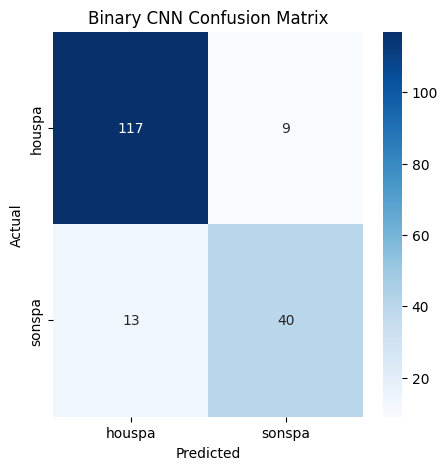

```python
cm = confusion_matrix(y_test, preds)

plt.figure(figsize=(5,5))

sns.heatmap(cm,annot=True,fmt='d',cmap='Blues',xticklabels=encoder.classes_,yticklabels=encoder.classes_)

plt.xlabel("Predicted")
plt.ylabel("Actual")
plt.title("Binary CNN Confusion Matrix")

plt.show()
```

```python
test_loss, test_acc = baseline_model.evaluate(X_test,y_test)
print("Test Accuracy:", test_acc)
```

```
6/6 ━━━━━━━━━━━━━━━━━━━━ 3s 391ms/step - accuracy: 0.8900 - loss: 0.3289
Test Accuracy: 0.8770949840545654
```

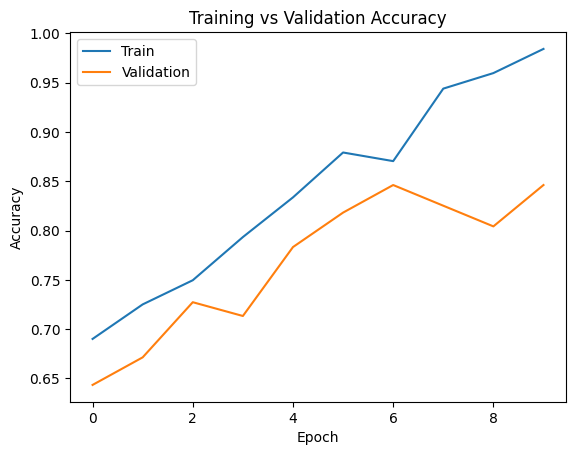

```python
plt.plot(history.history['accuracy'])
plt.plot(history.history['val_accuracy'])
plt.title("Training vs Validation Accuracy")
plt.xlabel("Epoch")
plt.ylabel("Accuracy")
plt.legend(['Train', 'Validation'])
plt.show()
```

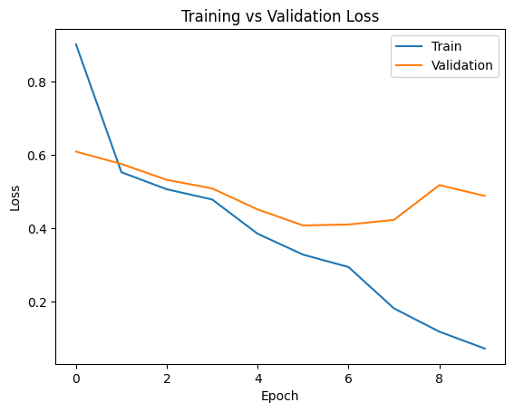

```python
plt.plot(history.history['loss'])
plt.plot(history.history['val_loss'])
plt.title("Training vs Validation Loss")
plt.xlabel("Epoch")
plt.ylabel("Loss")
plt.legend(['Train', 'Validation'])
plt.show()
```

### Second Binary Model

```python
# balanced class weights
class_weights = compute_class_weight(class_weight='balanced',classes=np.unique(y_train),y=y_train)
class_weights = dict(enumerate(class_weights))
print(class_weights)
```

```
{0: 0.7083333333333334, 1: 1.7}
```

```python
# second binary model
baseline_model = Sequential([
    Conv2D(32,(3,3),activation='relu',input_shape=(128, 517, 1)),
    MaxPooling2D((2,2)),
    Conv2D(64,(3,3),activation='relu'),
    MaxPooling2D((2,2)),
    Flatten(),
    Dense(64, activation='relu'),
    Dropout(0.5),
    Dense(1, activation='sigmoid')])
```

```python
# compile
baseline_model.compile(optimizer='adam',loss='binary_crossentropy',metrics=['accuracy'])
baseline_model.summary()
```

```
Model: "sequential_1"
```

```
┏━━━━━━━━━━━━━━━━━━━━━━━━━━━━━━━━━┳━━━━━━━━━━━━━━━━━━━━━━━━┳━━━━━━━━━━━━━━━┓
┃ Layer (type)                    ┃ Output Shape           ┃       Param # ┃
┡━━━━━━━━━━━━━━━━━━━━━━━━━━━━━━━━━╇━━━━━━━━━━━━━━━━━━━━━━━━╇━━━━━━━━━━━━━━━┩
│ conv2d_2 (Conv2D)               │ (None, 126, 515, 32)   │           320 │
├─────────────────────────────────┼────────────────────────┼───────────────┤
│ max_pooling2d_2 (MaxPooling2D)  │ (None, 63, 257, 32)    │             0 │
├─────────────────────────────────┼────────────────────────┼───────────────┤
│ conv2d_3 (Conv2D)               │ (None, 61, 255, 64)    │        18,496 │
├─────────────────────────────────┼────────────────────────┼───────────────┤
│ max_pooling2d_3 (MaxPooling2D)  │ (None, 30, 127, 64)    │             0 │
├─────────────────────────────────┼────────────────────────┼───────────────┤
│ flatten_1 (Flatten)             │ (None, 243840)         │             0 │
├─────────────────────────────────┼────────────────────────┼───────────────┤
│ dense_2 (Dense)                 │ (None, 64)             │    15,605,824 │
├─────────────────────────────────┼────────────────────────┼───────────────┤
│ dropout (Dropout)               │ (None, 64)             │             0 │
├─────────────────────────────────┼────────────────────────┼───────────────┤
│ dense_3 (Dense)                 │ (None, 1)              │            65 │
└─────────────────────────────────┴────────────────────────┴───────────────┘
```

```
 Total params: 15,624,705 (59.60 MB)
```

```
 Trainable params: 15,624,705 (59.60 MB)
```

```
 Non-trainable params: 0 (0.00 B)
```

```python
# early stop
early_stop = EarlyStopping(monitor='val_loss',patience=3,restore_best_weights=True)
```

```python
start_time = time.time()
history = baseline_model.fit(X_train,y_train,epochs=30,batch_size=16,validation_split=0.2,class_weight=class_weights,callbacks=[early_stop],verbose=1)
end_time = time.time()
training_time = end_time - start_time
print(f"\nTotal Training Time: {training_time:.2f} seconds")
```

```
36/36 ━━━━━━━━━━━━━━━━━━━━ 36s 905ms/step - accuracy: 0.6224 - loss: 0.7542 - val_accuracy: 0.6573 - val_loss: 0.6725
36/36 ━━━━━━━━━━━━━━━━━━━━ 36s 799ms/step - accuracy: 0.6515 - loss: 0.6840 - val_accuracy: 0.6434 - val_loss: 0.6299
36/36 ━━━━━━━━━━━━━━━━━━━━ 39s 1s/step - accuracy: 0.5827 - loss: 0.6915 - val_accuracy: 0.6503 - val_loss: 0.6276
36/36 ━━━━━━━━━━━━━━━━━━━━ 35s 955ms/step - accuracy: 0.7112 - loss: 0.6124 - val_accuracy: 0.6084 - val_loss: 0.6237
36/36 ━━━━━━━━━━━━━━━━━━━━ 32s 899ms/step - accuracy: 0.6045 - loss: 0.5990 - val_accuracy: 0.7622 - val_loss: 0.5451
36/36 ━━━━━━━━━━━━━━━━━━━━ 32s 881ms/step - accuracy: 0.7481 - loss: 0.5484 - val_accuracy: 0.6573 - val_loss: 0.5553
36/36 ━━━━━━━━━━━━━━━━━━━━ 30s 836ms/step - accuracy: 0.7704 - loss: 0.5102 - val_accuracy: 0.7552 - val_loss: 0.5191
36/36 ━━━━━━━━━━━━━━━━━━━━ 31s 856ms/step - accuracy: 0.7976 - loss: 0.4526 - val_accuracy: 0.7692 - val_loss: 0.4979
36/36 ━━━━━━━━━━━━━━━━━━━━ 33s 926ms/step - accuracy: 0.8372 - loss: 0.3253 - val_accuracy: 0.7762 - val_loss: 0.5292
36/36 ━━━━━━━━━━━━━━━━━━━━ 32s 881ms/step - accuracy: 0.8996 - loss: 0.2906 - val_accuracy: 0.7622 - val_loss: 0.5118
36/36 ━━━━━━━━━━━━━━━━━━━━ 32s 904ms/step - accuracy: 0.9451 - loss: 0.1870 - val_accuracy: 0.8112 - val_loss: 0.5619

Total Training Time: 369.92 seconds
```

```python
# evaluate
test_loss, test_acc = baseline_model.evaluate(X_test,y_test,verbose=0)
print(f"\nTest Accuracy: {test_acc:.4f}")
print(f"Test Loss: {test_loss:.4f}")
```

```
Test Accuracy: 0.7765
Test Loss: 0.4391
```

```python
# let's predict
pred_probs = baseline_model.predict(X_test)
preds = (pred_probs > 0.5).astype(int)
```

```
6/6 ━━━━━━━━━━━━━━━━━━━━ 2s 365ms/step
```

```python
print(classification_report(y_test,preds,target_names=encoder.classes_))
```

```
              precision    recall  f1-score   support

      houspa       0.88      0.79      0.83       126
      sonspa       0.60      0.74      0.66        53

    accuracy                           0.78       179
   macro avg       0.74      0.76      0.75       179
weighted avg       0.80      0.78      0.78       179
```

### Binary Evaluation and Comparison

The base model produces a strong test accuracy, showcasing ability to predict House Sparrow birds. Precision, recall and F-1 are important here; they are indicators of the class imbalance between the two birds. While accuracy was high, Song Sparrow performance was poorer, specifically in recall and F-1. The model occasionaly failed to identify true Song Sparrow recordings.

The second model has a similar architecture, but with balanced class weights, dropout and early stopping. This proved not useful. The revised model produced lower performance. Precision and F-1 of Song Sparrow decreased significantly; this means that the model became overly sensitive to minority class predictions and introduced more false positives.

| Parameters | First Model | Second Model |
| --- | --- | --- |
| Number of Convolutional Layers | 2 | 2 |
| Number of Pooling Layers | 2 | 2 |
| Number of Flatten Layers | 1 | 1 |
| Number of Dense Layers | 2 | 2 |
| Number of Dropout Layers | 0 | 1 |
| Class Weights | Not applied | Balanced |
| Early Stopping | Not applied | Yes |
| Accuracy | 0.88 | 0.78 |
| **Preferred Model** | Yes | No |

| Results | First Model | Second Model |
| --- | --- | --- |
| Precision (House Sparrow) | 0.90 | 0.88 |
| Precision (Song Sparrow) | 0.82 | 0.60 |
| Recall (House Sparrow) | 0.93 | 0.79 |
| Recall (Song Sparrow) | 0.75 | 0.74 |
| F-1 Score (House Sparrow) | 0.91 | 0.83 |
| F-1 Score (Song Sparrow) | 0.78 | 0.66 |

## Multiclass Classification Model

```python
# encode lables
multi_encoder = LabelEncoder()
y_multi_encoded = multi_encoder.fit_transform(y_multi)
print(multi_encoder.classes_)
print("Number of classes:", len(multi_encoder.classes_))
```

```
['amecro' 'amerob' 'bewwre' 'bkcchi' 'daejun' 'houfin' 'houspa' 'norfli'
 'rewbla' 'sonspa' 'spotow' 'whcspa']
Number of classes: 12
```

```python
# train test split
X_train_multi, X_test_multi, y_train_multi, y_test_multi = train_test_split(X_multi,y_multi_encoded,test_size=0.2,stratify=y_multi_encoded,random_state=42)
print(X_train_multi.shape)
print(X_test_multi.shape)
```

```
(2880, 128, 517, 1)
(720, 128, 517, 1)
```

```python
# one hot encode
num_classes = len(np.unique(y_multi_encoded))
y_train_multi_cat = to_categorical(y_train_multi,num_classes=num_classes)
y_test_multi_cat = to_categorical(y_test_multi,num_classes=num_classes)
```

### First Multiclass Model

```python
# base architecture
multi_model1 = Sequential([
    Conv2D(32,(3,3),activation='relu',input_shape=(128, 517, 1)),
    MaxPooling2D((2,2)),
    Conv2D(64,(3,3),activation='relu'),
    MaxPooling2D((2,2)),
    Flatten(),
    Dense(128, activation='relu'),
    Dense(num_classes, activation='softmax')])
```

```python
# compile
multi_model1.compile(optimizer='adam',loss='categorical_crossentropy',metrics=['accuracy'])
multi_model1.summary()
```

```
Model: "sequential_2"
```

```
┏━━━━━━━━━━━━━━━━━━━━━━━━━━━━━━━━━┳━━━━━━━━━━━━━━━━━━━━━━━━┳━━━━━━━━━━━━━━━┓
┃ Layer (type)                    ┃ Output Shape           ┃       Param # ┃
┡━━━━━━━━━━━━━━━━━━━━━━━━━━━━━━━━━╇━━━━━━━━━━━━━━━━━━━━━━━━╇━━━━━━━━━━━━━━━┩
│ conv2d_4 (Conv2D)               │ (None, 126, 515, 32)   │           320 │
├─────────────────────────────────┼────────────────────────┼───────────────┤
│ max_pooling2d_4 (MaxPooling2D)  │ (None, 63, 257, 32)    │             0 │
├─────────────────────────────────┼────────────────────────┼───────────────┤
│ conv2d_5 (Conv2D)               │ (None, 61, 255, 64)    │        18,496 │
├─────────────────────────────────┼────────────────────────┼───────────────┤
│ max_pooling2d_5 (MaxPooling2D)  │ (None, 30, 127, 64)    │             0 │
├─────────────────────────────────┼────────────────────────┼───────────────┤
│ flatten_2 (Flatten)             │ (None, 243840)         │             0 │
├─────────────────────────────────┼────────────────────────┼───────────────┤
│ dense_4 (Dense)                 │ (None, 128)            │    31,211,648 │
├─────────────────────────────────┼────────────────────────┼───────────────┤
│ dense_5 (Dense)                 │ (None, 12)             │         1,548 │
└─────────────────────────────────┴────────────────────────┴───────────────┘
```

```
 Total params: 31,232,012 (119.14 MB)
```

```
 Trainable params: 31,232,012 (119.14 MB)
```

```
 Non-trainable params: 0 (0.00 B)
```

```python
# early stopping
early_stop_multi = EarlyStopping(monitor='val_loss',patience=3,restore_best_weights=True)
```

```python
start_time = time.time()

history_multi1 = multi_model1.fit(
    X_train_multi,
    y_train_multi_cat,
    epochs=30,
    batch_size=16,
    validation_split=0.2,
    callbacks=[early_stop_multi],
    verbose=1)

end_time = time.time()

print(f"\nTraining Time: {end_time - start_time:.2f} seconds")
```

```
144/144 ━━━━━━━━━━━━━━━━━━━━ 178s 1s/step - accuracy: 0.1033 - loss: 3.6265 - val_accuracy: 0.1719 - val_loss: 2.3476
144/144 ━━━━━━━━━━━━━━━━━━━━ 161s 917ms/step - accuracy: 0.3534 - loss: 1.9679 - val_accuracy: 0.3177 - val_loss: 2.1128
144/144 ━━━━━━━━━━━━━━━━━━━━ 138s 885ms/step - accuracy: 0.6825 - loss: 1.0996 - val_accuracy: 0.4253 - val_loss: 1.9940
144/144 ━━━━━━━━━━━━━━━━━━━━ 125s 866ms/step - accuracy: 0.8876 - loss: 0.4083 - val_accuracy: 0.4479 - val_loss: 2.2864
144/144 ━━━━━━━━━━━━━━━━━━━━ 156s 1s/step - accuracy: 0.9539 - loss: 0.2178 - val_accuracy: 0.4983 - val_loss: 2.3865
144/144 ━━━━━━━━━━━━━━━━━━━━ 160s 1s/step - accuracy: 0.9914 - loss: 0.0557 - val_accuracy: 0.5347 - val_loss: 2.4289

Training Time: 920.12 seconds
```

```python
# evaluate
test_loss_multi1, test_acc_multi1 = multi_model1.evaluate(X_test_multi,y_test_multi_cat,verbose=0)

print(f"\nTest Accuracy: {test_acc_multi1:.4f}")
print(f"Test Loss: {test_loss_multi1:.4f}")
```

```
Test Accuracy: 0.4556
Test Loss: 1.9292
```

```python
pred_probs_multi1 = multi_model1.predict(X_test_multi)
preds_multi1 = np.argmax(pred_probs_multi1,axis=1)
```

```
23/23 ━━━━━━━━━━━━━━━━━━━━ 9s 373ms/step
```

```python
print(classification_report(y_test_multi,preds_multi1,target_names=multi_encoder.classes_))
```

```
              precision    recall  f1-score   support

      amecro       0.55      0.48      0.51        60
      amerob       0.59      0.48      0.53        60
      bewwre       0.27      0.37      0.31        60
      bkcchi       0.46      0.70      0.55        60
      daejun       0.40      0.38      0.39        60
      houfin       0.76      0.42      0.54        60
      houspa       0.49      0.30      0.37        60
      norfli       0.79      0.45      0.57        60
      rewbla       0.43      0.48      0.46        60
      sonspa       0.53      0.27      0.36        60
      spotow       0.32      0.42      0.36        60
      whcspa       0.39      0.72      0.51        60

    accuracy                           0.46       720
   macro avg       0.50      0.46      0.46       720
weighted avg       0.50      0.46      0.46       720
```

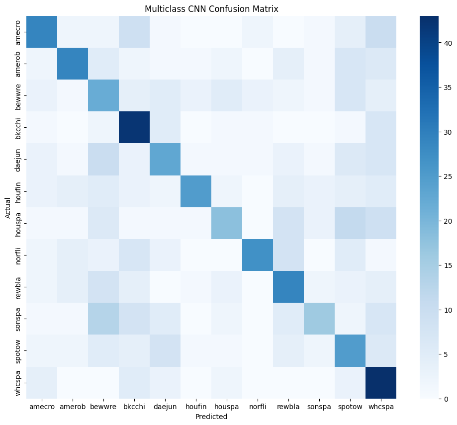

```python
cm_multi1 = confusion_matrix(y_test_multi,preds_multi1)
plt.figure(figsize=(12,10))
sns.heatmap(cm_multi1,cmap='Blues',xticklabels=multi_encoder.classes_,yticklabels=multi_encoder.classes_)
plt.title("Multiclass CNN Confusion Matrix")
plt.xlabel("Predicted")
plt.ylabel("Actual")
plt.show()
```

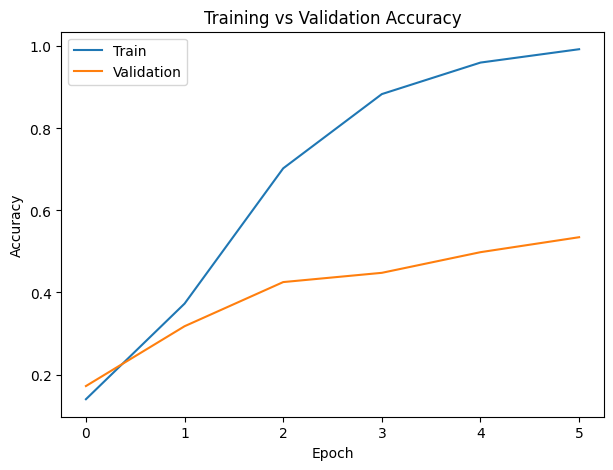

```python
plt.figure(figsize=(7,5))
plt.plot(history_multi1.history['accuracy'])
plt.plot(history_multi1.history['val_accuracy'])
plt.title("Training vs Validation Accuracy")
plt.xlabel("Epoch")
plt.ylabel("Accuracy")
plt.legend(['Train', 'Validation'])
plt.show()
```

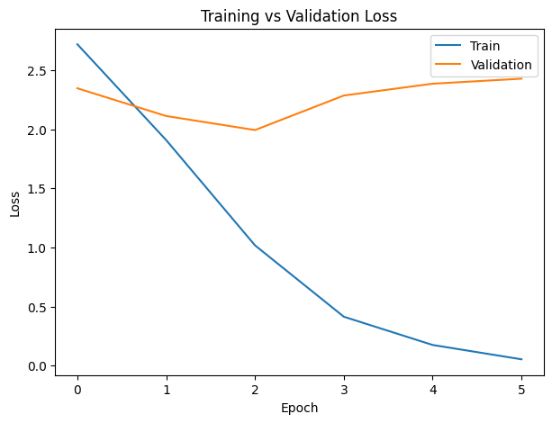

```python
plt.figure(figsize=(7,5))

plt.plot(history_multi1.history['loss'])
plt.plot(history_multi1.history['val_loss'])

plt.title("Training vs Validation Loss")

plt.xlabel("Epoch")
plt.ylabel("Loss")

plt.legend(['Train', 'Validation'])

plt.show()
```

### Second Multiclass Model

```python
# architecture
multi_model2 = Sequential([
    Conv2D(32,(3,3),activation='relu',padding='same',input_shape=(128, 517, 1)),
    BatchNormalization(),
    MaxPooling2D((2,2)),
    Conv2D(64,(3,3),activation='relu',padding='same'),
    BatchNormalization(),
    MaxPooling2D((2,2)),
    Conv2D(128,(3,3),activation='relu',padding='same'),
    BatchNormalization(),
    MaxPooling2D((2,2)),
    GlobalAveragePooling2D(),
    Dense(128, activation='relu'),
    Dropout(0.4),
    Dense(num_classes, activation='softmax')])

# compile
multi_model2.compile(optimizer=Adam(learning_rate=0.0003),
                     loss='categorical_crossentropy',
                     metrics=['accuracy'])
multi_model2.summary()


# early stopping
early_stop_multi2 = EarlyStopping(monitor='val_loss',patience=5,restore_best_weights=True)
```

```
Model: "sequential_3"
```

```
┏━━━━━━━━━━━━━━━━━━━━━━━━━━━━━━━━━┳━━━━━━━━━━━━━━━━━━━━━━━━┳━━━━━━━━━━━━━━━┓
┃ Layer (type)                    ┃ Output Shape           ┃       Param # ┃
┡━━━━━━━━━━━━━━━━━━━━━━━━━━━━━━━━━╇━━━━━━━━━━━━━━━━━━━━━━━━╇━━━━━━━━━━━━━━━┩
│ conv2d_9 (Conv2D)               │ (None, 128, 517, 32)   │           320 │
├─────────────────────────────────┼────────────────────────┼───────────────┤
│ batch_normalization_5           │ (None, 128, 517, 32)   │           128 │
│ (BatchNormalization)            │                        │               │
├─────────────────────────────────┼────────────────────────┼───────────────┤
│ max_pooling2d_9 (MaxPooling2D)  │ (None, 64, 258, 32)    │             0 │
├─────────────────────────────────┼────────────────────────┼───────────────┤
│ conv2d_10 (Conv2D)              │ (None, 64, 258, 64)    │        18,496 │
├─────────────────────────────────┼────────────────────────┼───────────────┤
│ batch_normalization_6           │ (None, 64, 258, 64)    │           256 │
│ (BatchNormalization)            │                        │               │
├─────────────────────────────────┼────────────────────────┼───────────────┤
│ max_pooling2d_10 (MaxPooling2D) │ (None, 32, 129, 64)    │             0 │
├─────────────────────────────────┼────────────────────────┼───────────────┤
│ conv2d_11 (Conv2D)              │ (None, 32, 129, 128)   │        73,856 │
├─────────────────────────────────┼────────────────────────┼───────────────┤
│ batch_normalization_7           │ (None, 32, 129, 128)   │           512 │
│ (BatchNormalization)            │                        │               │
├─────────────────────────────────┼────────────────────────┼───────────────┤
│ max_pooling2d_11 (MaxPooling2D) │ (None, 16, 64, 128)    │             0 │
├─────────────────────────────────┼────────────────────────┼───────────────┤
│ global_average_pooling2d        │ (None, 128)            │             0 │
│ (GlobalAveragePooling2D)        │                        │               │
├─────────────────────────────────┼────────────────────────┼───────────────┤
│ dense_6 (Dense)                 │ (None, 128)            │        16,512 │
├─────────────────────────────────┼────────────────────────┼───────────────┤
│ dropout_1 (Dropout)             │ (None, 128)            │             0 │
├─────────────────────────────────┼────────────────────────┼───────────────┤
│ dense_7 (Dense)                 │ (None, 12)             │         1,548 │
└─────────────────────────────────┴────────────────────────┴───────────────┘
```

```
 Total params: 111,628 (436.05 KB)
```

```
 Trainable params: 111,180 (434.30 KB)
```

```
 Non-trainable params: 448 (1.75 KB)
```

```python
start_time = time.time()

history_multi2 = multi_model2.fit(
    X_train_multi,
    y_train_multi_cat,
    epochs=40,
    batch_size=16,
    validation_split=0.2,
    callbacks=[early_stop_multi2],
    verbose=1)

end_time = time.time()

training_time = end_time - start_time

print(f"\nTraining Time: {training_time:.2f} seconds")
```

```
144/144 ━━━━━━━━━━━━━━━━━━━━ 251s 2s/step - accuracy: 0.0976 - loss: 2.6348 - val_accuracy: 0.1007 - val_loss: 2.5527
144/144 ━━━━━━━━━━━━━━━━━━━━ 253s 2s/step - accuracy: 0.1276 - loss: 2.4410 - val_accuracy: 0.0885 - val_loss: 2.6607
144/144 ━━━━━━━━━━━━━━━━━━━━ 280s 2s/step - accuracy: 0.1611 - loss: 2.3769 - val_accuracy: 0.0868 - val_loss: 2.6081
144/144 ━━━━━━━━━━━━━━━━━━━━ 316s 2s/step - accuracy: 0.1611 - loss: 2.3694 - val_accuracy: 0.1285 - val_loss: 2.4591
144/144 ━━━━━━━━━━━━━━━━━━━━ 286s 2s/step - accuracy: 0.1653 - loss: 2.3422 - val_accuracy: 0.1649 - val_loss: 2.3840
144/144 ━━━━━━━━━━━━━━━━━━━━ 253s 2s/step - accuracy: 0.1592 - loss: 2.3468 - val_accuracy: 0.1753 - val_loss: 2.2945
144/144 ━━━━━━━━━━━━━━━━━━━━ 239s 2s/step - accuracy: 0.1985 - loss: 2.3250 - val_accuracy: 0.1771 - val_loss: 2.3659
144/144 ━━━━━━━━━━━━━━━━━━━━ 238s 2s/step - accuracy: 0.2051 - loss: 2.3059 - val_accuracy: 0.1823 - val_loss: 2.2877
144/144 ━━━━━━━━━━━━━━━━━━━━ 236s 2s/step - accuracy: 0.2072 - loss: 2.2941 - val_accuracy: 0.2083 - val_loss: 2.2567
144/144 ━━━━━━━━━━━━━━━━━━━━ 234s 2s/step - accuracy: 0.2178 - loss: 2.2516 - val_accuracy: 0.1927 - val_loss: 2.2859
144/144 ━━━━━━━━━━━━━━━━━━━━ 232s 2s/step - accuracy: 0.2353 - loss: 2.2327 - val_accuracy: 0.1215 - val_loss: 2.6372
144/144 ━━━━━━━━━━━━━━━━━━━━ 232s 2s/step - accuracy: 0.2469 - loss: 2.2003 - val_accuracy: 0.1979 - val_loss: 2.3075
144/144 ━━━━━━━━━━━━━━━━━━━━ 231s 2s/step - accuracy: 0.2847 - loss: 2.1377 - val_accuracy: 0.2118 - val_loss: 2.2748
144/144 ━━━━━━━━━━━━━━━━━━━━ 238s 2s/step - accuracy: 0.2811 - loss: 2.1320 - val_accuracy: 0.2257 - val_loss: 2.1968
144/144 ━━━━━━━━━━━━━━━━━━━━ 254s 2s/step - accuracy: 0.2813 - loss: 2.1224 - val_accuracy: 0.2483 - val_loss: 2.2155
144/144 ━━━━━━━━━━━━━━━━━━━━ 255s 2s/step - accuracy: 0.2917 - loss: 2.0883 - val_accuracy: 0.2326 - val_loss: 2.2424
144/144 ━━━━━━━━━━━━━━━━━━━━ 270s 2s/step - accuracy: 0.3182 - loss: 2.0638 - val_accuracy: 0.2865 - val_loss: 2.0964
144/144 ━━━━━━━━━━━━━━━━━━━━ 259s 2s/step - accuracy: 0.3234 - loss: 1.9993 - val_accuracy: 0.2726 - val_loss: 2.1733
144/144 ━━━━━━━━━━━━━━━━━━━━ 308s 2s/step - accuracy: 0.3336 - loss: 1.9615 - val_accuracy: 0.2083 - val_loss: 2.3179
144/144 ━━━━━━━━━━━━━━━━━━━━ 306s 2s/step - accuracy: 0.3437 - loss: 1.9500 - val_accuracy: 0.3160 - val_loss: 2.0521
144/144 ━━━━━━━━━━━━━━━━━━━━ 293s 2s/step - accuracy: 0.3609 - loss: 1.9010 - val_accuracy: 0.3333 - val_loss: 1.9655
144/144 ━━━━━━━━━━━━━━━━━━━━ 264s 2s/step - accuracy: 0.3960 - loss: 1.8317 - val_accuracy: 0.2257 - val_loss: 2.3132
144/144 ━━━━━━━━━━━━━━━━━━━━ 362s 3s/step - accuracy: 0.3876 - loss: 1.8114 - val_accuracy: 0.2691 - val_loss: 2.2111
144/144 ━━━━━━━━━━━━━━━━━━━━ 315s 2s/step - accuracy: 0.3991 - loss: 1.7870 - val_accuracy: 0.2674 - val_loss: 2.7238
144/144 ━━━━━━━━━━━━━━━━━━━━ 318s 2s/step - accuracy: 0.4407 - loss: 1.7091 - val_accuracy: 0.3872 - val_loss: 1.8821
144/144 ━━━━━━━━━━━━━━━━━━━━ 269s 2s/step - accuracy: 0.4645 - loss: 1.6264 - val_accuracy: 0.2604 - val_loss: 2.6847
144/144 ━━━━━━━━━━━━━━━━━━━━ 276s 2s/step - accuracy: 0.4666 - loss: 1.6156 - val_accuracy: 0.2986 - val_loss: 2.4128
144/144 ━━━━━━━━━━━━━━━━━━━━ 313s 2s/step - accuracy: 0.5009 - loss: 1.5063 - val_accuracy: 0.3212 - val_loss: 1.9710
144/144 ━━━━━━━━━━━━━━━━━━━━ 262s 2s/step - accuracy: 0.5236 - loss: 1.4868 - val_accuracy: 0.4462 - val_loss: 1.7284
144/144 ━━━━━━━━━━━━━━━━━━━━ 299s 2s/step - accuracy: 0.5481 - loss: 1.4177 - val_accuracy: 0.3646 - val_loss: 1.8911
144/144 ━━━━━━━━━━━━━━━━━━━━ 327s 2s/step - accuracy: 0.5326 - loss: 1.4252 - val_accuracy: 0.3038 - val_loss: 2.0193
144/144 ━━━━━━━━━━━━━━━━━━━━ 289s 2s/step - accuracy: 0.5567 - loss: 1.3683 - val_accuracy: 0.3941 - val_loss: 1.7611
144/144 ━━━━━━━━━━━━━━━━━━━━ 526s 4s/step - accuracy: 0.5723 - loss: 1.3068 - val_accuracy: 0.4514 - val_loss: 1.6534
144/144 ━━━━━━━━━━━━━━━━━━━━ 445s 3s/step - accuracy: 0.6293 - loss: 1.2213 - val_accuracy: 0.2413 - val_loss: 2.7922
144/144 ━━━━━━━━━━━━━━━━━━━━ 438s 3s/step - accuracy: 0.5934 - loss: 1.2209 - val_accuracy: 0.3021 - val_loss: 2.5745
144/144 ━━━━━━━━━━━━━━━━━━━━ 363s 3s/step - accuracy: 0.6258 - loss: 1.1758 - val_accuracy: 0.4913 - val_loss: 1.5464
144/144 ━━━━━━━━━━━━━━━━━━━━ 403s 3s/step - accuracy: 0.6261 - loss: 1.1658 - val_accuracy: 0.5139 - val_loss: 1.4868
144/144 ━━━━━━━━━━━━━━━━━━━━ 597s 4s/step - accuracy: 0.6852 - loss: 1.0177 - val_accuracy: 0.5451 - val_loss: 1.3951
144/144 ━━━━━━━━━━━━━━━━━━━━ 471s 3s/step - accuracy: 0.6798 - loss: 1.0157 - val_accuracy: 0.3889 - val_loss: 2.4711
144/144 ━━━━━━━━━━━━━━━━━━━━ 458s 3s/step - accuracy: 0.6746 - loss: 1.0414 - val_accuracy: 0.5938 - val_loss: 1.2909

Training Time: 12462.54 seconds
```

```python
# evaluate
test_loss_multi2, test_acc_multi2 = multi_model2.evaluate(X_test_multi,y_test_multi_cat,verbose=0)
print(f"\nTest Accuracy: {test_acc_multi2:.4f}")
print(f"Test Loss: {test_loss_multi2:.4f}")
```

```
Test Accuracy: 0.5625
Test Loss: 1.3447
```

```python
# predictions
pred_probs_multi2 = multi_model2.predict(X_test_multi)
preds_multi2 = np.argmax(pred_probs_multi2,axis=1)
```

```
23/23 ━━━━━━━━━━━━━━━━━━━━ 26s 1s/step
```

```python
print(classification_report(y_test_multi,preds_multi2,target_names=multi_encoder.classes_))
```

```
              precision    recall  f1-score   support

      amecro       0.60      0.63      0.62        60
      amerob       0.54      0.37      0.44        60
      bewwre       0.45      0.45      0.45        60
      bkcchi       0.65      0.75      0.70        60
      daejun       0.75      0.55      0.63        60
      houfin       0.67      0.63      0.65        60
      houspa       0.69      0.77      0.72        60
      norfli       0.49      0.90      0.64        60
      rewbla       0.46      0.28      0.35        60
      sonspa       0.56      0.37      0.44        60
      spotow       0.42      0.18      0.26        60
      whcspa       0.49      0.87      0.62        60

    accuracy                           0.56       720
   macro avg       0.56      0.56      0.54       720
weighted avg       0.56      0.56      0.54       720
```

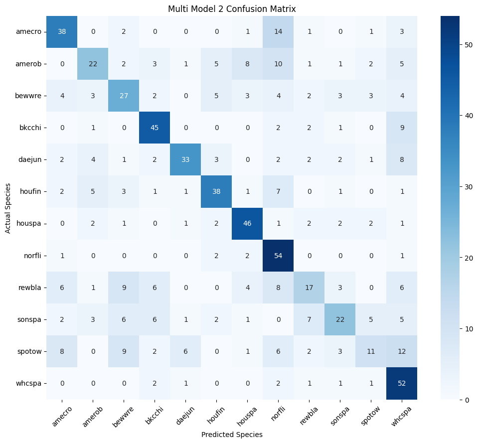

```python
cm_multi2 = confusion_matrix(y_test_multi,preds_multi2)
plt.figure(figsize=(12,10))
sns.heatmap(
    cm_multi2,
    annot=True,
    fmt='d',
    cmap='Blues',
    xticklabels=multi_encoder.classes_,
    yticklabels=multi_encoder.classes_)
plt.title("Multi Model 2 Confusion Matrix")
plt.xlabel("Predicted Species")
plt.ylabel("Actual Species")
plt.xticks(rotation=45)
plt.yticks(rotation=0)
plt.show()
```

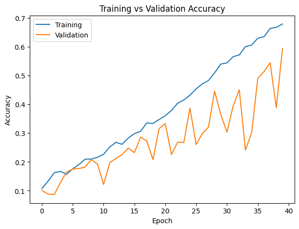

```python
plt.figure(figsize=(7,5))
plt.plot(history_multi2.history['accuracy'])
plt.plot(history_multi2.history['val_accuracy'])
plt.title("Training vs Validation Accuracy")
plt.xlabel("Epoch")
plt.ylabel("Accuracy")
plt.legend(['Training', 'Validation'])
plt.show()
```

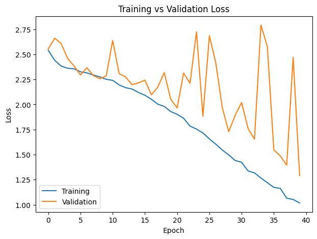

```python
plt.figure(figsize=(7,5))
plt.plot(history_multi2.history['loss'])
plt.plot(history_multi2.history['val_loss'])
plt.title("Training vs Validation Loss")
plt.xlabel("Epoch")
plt.ylabel("Loss")
plt.legend(['Training', 'Validation'])
plt.show()
```

## Prediction Using 3 Audios

- Preprocess audio function:
  - load audio
  - keep first 3 seconds
  - create spectrograms
  - resize dimensions
  - add cnn dimensions

```python
def preprocess_audio(file_path):
    audio, sr = librosa.load(file_path,sr=22050)
    audio = audio[:3 * sr]

    spectrogram = librosa.feature.melspectrogram(y=audio,sr=sr,n_mels=128)
    spectrogram_db = librosa.power_to_db(
        spectrogram,
        ref=np.max)


    spectrogram_db = (spectrogram_db - spectrogram_db.min()) / (spectrogram_db.max() - spectrogram_db.min())

    target_width = 517
    current_width = spectrogram_db.shape[1]
    if current_width < target_width:
        pad_width = target_width - current_width
        spectrogram_db = np.pad(
            spectrogram_db,
            ((0,0),(0,pad_width)),
            mode='constant')
    else:
        spectrogram_db = spectrogram_db[:, :target_width]

    spectrogram_db = spectrogram_db.reshape(1,128,517,1)

    return spectrogram_db
```

```python
def plot_spectrogram(spec, title):
    plt.figure(figsize=(10,4))
    plt.imshow(
        spec[0,:,:,0],
        aspect='auto',
        origin='lower',
        cmap='magma')
    plt.title(title)
    plt.xlabel("Time")
    plt.ylabel("Frequency")
    plt.colorbar(label='Normalized Intensity')
    plt.show()
```

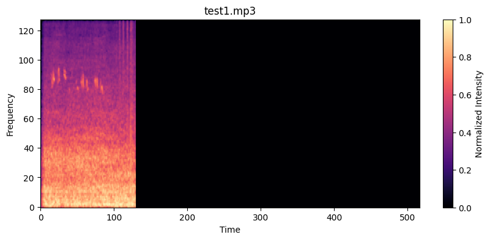

```
1/1 ━━━━━━━━━━━━━━━━━━━━ 0s 53ms/step

Top Prediction: whcspa

Top 5 Probabilities:
whcspa: 0.1909
houspa: 0.1547
daejun: 0.1121
bkcchi: 0.1018
spotow: 0.0843
```

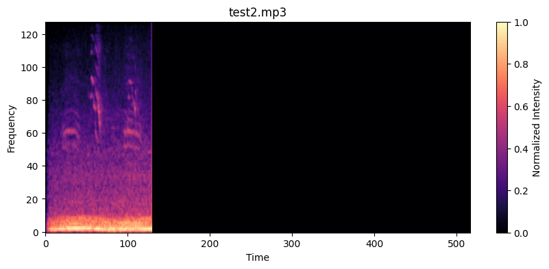

```
1/1 ━━━━━━━━━━━━━━━━━━━━ 0s 54ms/step

Top Prediction: whcspa

Top 5 Probabilities:
whcspa: 0.1331
spotow: 0.1327
houspa: 0.1188
bkcchi: 0.1158
amecro: 0.0928
```

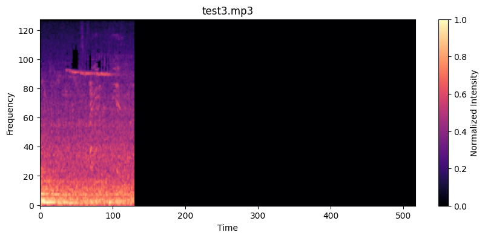

```
1/1 ━━━━━━━━━━━━━━━━━━━━ 0s 54ms/step

Top Prediction: whcspa

Top 5 Probabilities:
whcspa: 0.1858
bkcchi: 0.1832
houspa: 0.1539
rewbla: 0.1021
norfli: 0.0950
```

```python
test_files = ["test1.mp3","test2.mp3","test3.mp3"]

for file in test_files:
    spec = preprocess_audio(file)
    plot_spectrogram(spec, file)

    probs = multi_model2.predict(spec)[0]
    top_idx = np.argmax(probs)
    predicted_species = multi_encoder.classes_[top_idx]
    print(f"\nTop Prediction: {predicted_species}")

    # probabilities
    sorted_idx = np.argsort(probs)[::-1]
    print("\nTop 5 Probabilities:")

    for idx in sorted_idx[:5]:
        species = multi_encoder.classes_[idx]
        probability = probs[idx]
        print(f"{species}: {probability:.4f}")
```

# References

Xeno-Canto Bird Recordings Extended . Kaggle. (2020, September 14). https://www.kaggle.com/datasets/rohanrao/xeno-canto-bird-recordings-extended-a-m

Plants & python. 4.4 Masks - Plants & Python. (n.d.). https://plantsandpython.github.io/PlantsAndPython/G_4_DATA_ANALYSIS_WITH_PANDAS/0_Lessons/4.4_Masks.html

davids1992. (2019, April 26). Specaugment quick implementation. Kaggle. https://www.kaggle.com/code/davids1992/specaugment-quick-implementation

Librosa.feature.melspectrogram. librosa.feature.melspectrogram - librosa 0.11.0 documentation. (n.d.). https://librosa.org/doc/main/generated/librosa.feature.melspectrogram.html

Cornell Birdcall Identification. (n.d.-a). https://medium.com/@krgaurav45/cornell-birdcall-identification-afc43ca90b13

Dias, F. F., Ponti, M. A., & Minghim, R. (2025). Enhancing sound-based classification of birds and anurans with spectrogram representations and acoustic indices in neural network architectures. Ecological Informatics, 103232. https://doi.org/10.1016/j.ecoinf.2025.103232

Benbogart. (n.d.). Benbogart/bird_vocalization_classification. GitHub. https://github.com/benbogart/bird_vocalization_classification

Khare, Y. (2024, January 1). Hands-on guide to Librosa for Handling Audio files. Analytics Vidhya. https://www.analyticsvidhya.com/blog/2024/01/hands-on-guide-to-librosa-for-handling-audio-files/

Zhou, V. (2019, May 22). CNNs, Part 1: An Introduction to Convolutional Neural Networks. https://victorzhou.com/blog/intro-to-cnns-part-1/

Mipawa, A. (2022, June 8). Audio analysis with librosa. NEUROTECH AFRICA. https://blog.neurotech.africa/audio-analysis-with-librosa/